# Synthetic Control- California Smoking

The code is meant to answer a causal inference question:

“What was the effect of California’s 1988 tobacco control program (smoking ban) on cigarette sales?”

This is a policy evaluation problem in which California adopted an anti-smoking program, and the goal was to estimate how cigarette consumption would have evolved in California if the policy had never been implemented.

```r
library(Synth)
```

```r
library(ggplot2)
library(tidysynth)
library(dplyr)
data = read.csv("smoking (1).csv")
```

```r
head(data)
```

|  | state | year | cigsale | lnincome | beer | age15to24 | retprice | california | after_treatment |
| --- | --- | --- | --- | --- | --- | --- | --- | --- | --- |
| 1 | 1 | 1970 | 89.8 | NA | NA | 0.1788618 | 39.6 | False | False |
| 2 | 1 | 1971 | 95.4 | NA | NA | 0.1799278 | 42.7 | False | False |
| 3 | 1 | 1972 | 101.1 | 9.498476 | NA | 0.1809939 | 42.3 | False | False |
| 4 | 1 | 1973 | 102.9 | 9.550107 | NA | 0.1820599 | 42.1 | False | False |
| 5 | 1 | 1974 | 108.2 | 9.537163 | NA | 0.1831260 | 43.1 | False | False |
| 6 | 1 | 1975 | 111.7 | 9.540031 | NA | 0.1841921 | 46.6 | False | False |

```r
summary(data)
```

```
##      state         year         cigsale         lnincome           beer
##  Min.   : 1   Min.   :1970   Min.   : 40.7   Min.   : 9.397   Min.   : 2.50
##  1st Qu.:10   1st Qu.:1977   1st Qu.:100.9   1st Qu.: 9.739   1st Qu.:20.90
##  Median :20   Median :1985   Median :116.3   Median : 9.861   Median :23.30
##  Mean   :20   Mean   :1985   Mean   :118.9   Mean   : 9.862   Mean   :23.43
##  3rd Qu.:30   3rd Qu.:1993   3rd Qu.:130.5   3rd Qu.: 9.973   3rd Qu.:25.10
##  Max.   :39   Max.   :2000   Max.   :296.2   Max.   :10.487   Max.   :40.40
##                                              NA's   :195      NA's   :663
##    age15to24         retprice      california        after_treatment
##  Min.   :0.1294   Min.   : 27.3   Length:1209        Length:1209
##  1st Qu.:0.1658   1st Qu.: 50.0   Class :character   Class :character
##  Median :0.1781   Median : 95.5   Mode  :character   Mode  :character
##  Mean   :0.1755   Mean   :108.3
##  3rd Qu.:0.1867   3rd Qu.:158.4
##  Max.   :0.2037   Max.   :351.2
##  NA's   :390
```

```r
california_code = 3 #  the identifier for California (the treatment unit) to 3


the_states = unique(data$state)[unique(data$state) != california_code] # Creating a list of unique states excluding California

# Getting a list of unique years in the data and printing them
unique_years = unique(data$year)
print(unique_years)
```

```
##  [1] 1970 1971 1972 1973 1974 1975 1976 1977 1978 1979 1980 1981 1982 1983 1984
## [16] 1985 1986 1987 1988 1989 1990 1991 1992 1993 1994 1995 1996 1997 1998 1999
## [31] 2000
```

```r
time_pred = unique_years[unique_years <= 1988]
time_optimize_ssr = time_pred   # corrected (not 'time_predictors_prior')

synth_data = dataprep(
  foo = data,
  predictors = c("retprice", "cigsale", "lnincome", "beer", "age15to24"),
  predictors.op = "mean",
  dependent = "cigsale",
  unit.variable = "state",
  time.variable = "year",
  treatment.identifier = california_code,
  controls.identifier = the_states,
  time.predictors.prior = time_pred,
  time.optimize.ssr = time_optimize_ssr,
  time.plot = unique_years
)
```

[output not shown]

[output cut: 14 more lines]

[output not shown]

```r
synth_outcome = synth(data.prep.obj = synth_data)  # Estimating the synthetic control model using the prepared data object (synth_data) and store the results in synth_outcome
```

```
##
## X1, X0, Z1, Z0 all come directly from dataprep object.
##
##
## ****************
##  searching for synthetic control unit
##
##
## ****************
## ****************
## ****************
##
## MSPE (LOSS V): 24.59315
##
## solution.v:
##  0.1957939 0.7976307 0.005793528 0.000775129 6.8031e-06
##
## solution.w:
##  6.60255e-05 5.37347e-05 0.5625205 0.3505082 4.80968e-05 8.21968e-05 0.0001253972 6.74281e-05 6.50732e-05 0.000119217 0.0001086512 3.60852e-05 6.08754e-05 5.15911e-05 0.0001352792 6.00996e-05 8.29082e-05 0.000147518 0.0002096278 3.21683e-05 5.4645e-06 0.0001819029 4.16856e-05 0.000137318 0.000101…
```

```r
# Extracting the actual values of the dependent variable (cigsale) for the treated unit (California) from the prepared data object


#  Computing ATE (Base Synth)
val = synth_data$Y1plot
syn = synth_data$Y0plot %*% synth_outcome$solution.w

diffs = as.data.frame(val - syn)
colnames(diffs) = "H1"
diffs = diffs[row.names(diffs) > 1988, , drop = FALSE]
s_te = mean(diffs$H1)
print(s_te)
```

```
## [1] -20.2315
```

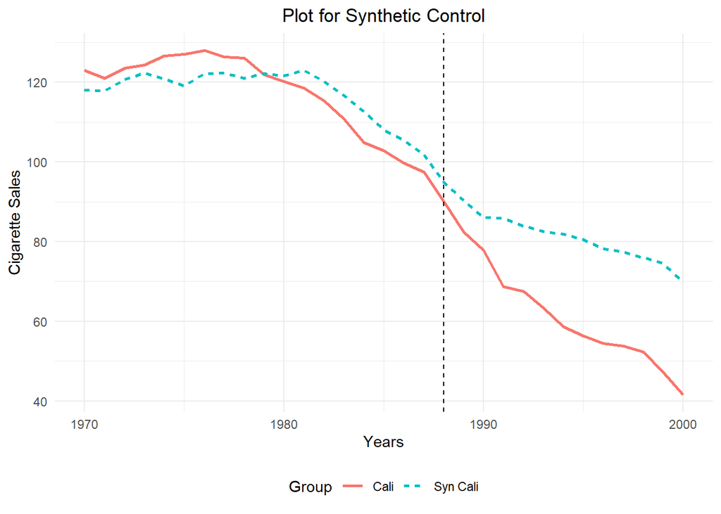

```r
plot_data = data.frame(
  year = rep(unique_years, 2),
  cigsale = c(synth_data$Y1plot, syn),
  group = rep(c("Cali", "Syn Cali"), each = length(unique_years))
)

ggplot(plot_data, aes(x = year, y = cigsale, color = group, linetype = group)) +
  geom_line(size = 1) +
  geom_vline(xintercept = 1988, linetype = "dashed", color = "black") +
  labs(title = "Plot for Synthetic Control",
       x = "Years", y = "Cigarette Sales",
       color = "Group", linetype = "Group") +
  theme_minimal() +
  theme(plot.title = element_text(hjust = 0.5),
        legend.position = "bottom")
```

```r
# Re-estimate with tidysynth
synth_results = data %>%
  synthetic_control(outcome = cigsale, unit = state, time = year,
                    i_unit = 3, i_time = 1988, generate_placebos = TRUE) %>%
  generate_predictor(time_window = 1970:1988,
                     ln_income = mean(lnincome, na.rm = TRUE),
                     ret_price = mean(retprice, na.rm = TRUE),
                     youth = mean(age15to24, na.rm = TRUE),
                     beersale = mean(beer, na.rm = TRUE),
                     cigsale = mean(cigsale, na.rm = TRUE)) %>%
  generate_weights(optimization_window = 1970:1988) %>%
  generate_control()

results_df = synth_results %>% grab_synthetic_control()
```

```r
ate = results_df %>%
  mutate(time_unit = as.numeric(time_unit)) %>%   # ensure it's numeric
  filter(time_unit > 1988) %>%
  mutate(diffs = real_y - synth_y) %>%
  summarize(ATE = mean(diffs, na.rm = TRUE)) %>%
  pull(ATE)

print(ate)
```

```
## [1] -20.2315
```

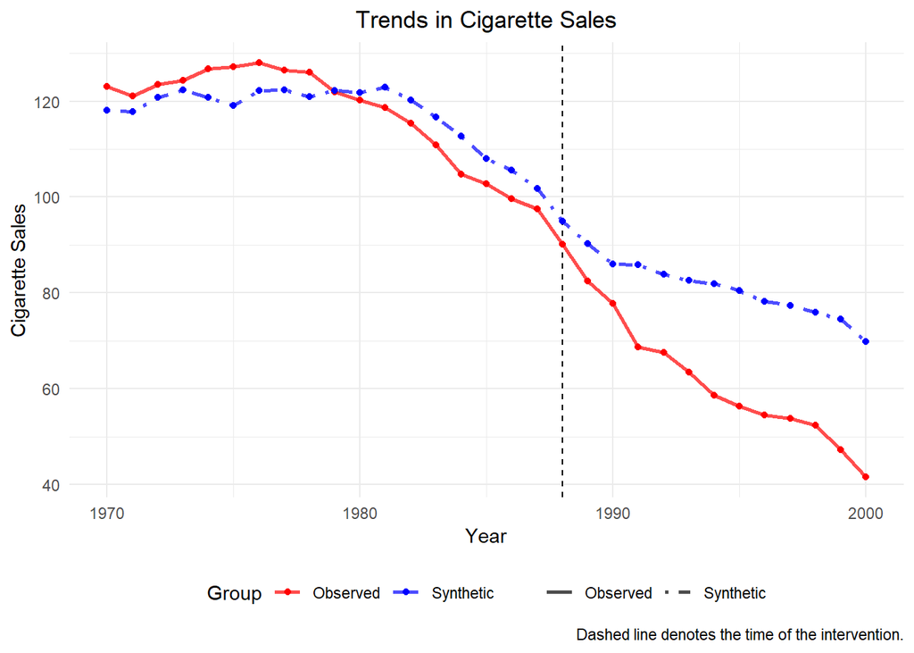

```r
#  Plot Trends (Tidysynth)
synth_results %>%
  plot_trends() +
  labs(title = "Trends in Cigarette Sales",
       x = "Year", y = "Cigarette Sales", color = "Group") +
  scale_color_manual(values = c("Observed" = "red", "Synthetic" = "blue")) +
  theme_minimal() +
  theme(plot.title = element_text(hjust = 0.5),
        legend.position = "bottom")
```

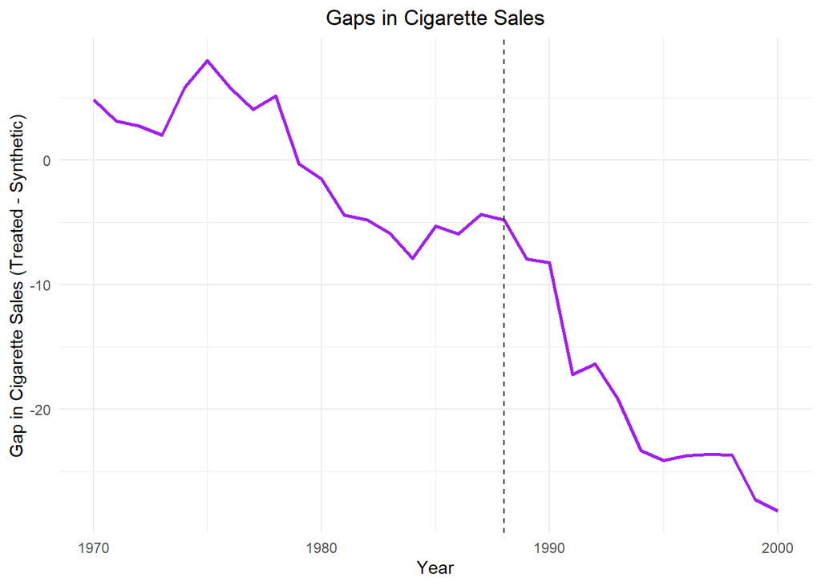

```r
# Gap Plot
gaps_data = results_df %>%
  mutate(gap = real_y - synth_y,
         time_unit = as.numeric(time_unit))   # make sure it's numeric for plotting

ggplot(gaps_data, aes(x = time_unit, y = gap)) +
  geom_line(size = 1, color = "purple") +
  geom_vline(xintercept = 1988, linetype = "dashed", color = "black") +
  labs(
    title = "Gaps in Cigarette Sales",
    x = "Year",
    y = "Gap in Cigarette Sales (Treated - Synthetic)"
  ) +
  theme_minimal() +
  theme(plot.title = element_text(hjust = 0.5))
```

Regrading {Synth} package and {tidysynth} package:

In this code The {Synth} package is used to implement the synthetic control method, where the goal is to create a synthetic control group that mimics the characteristics of the treatment group before the intervention. The synthetic control is constructed as a weighted average of the control units. The {Synth} package is specifically designed for synthetic control analysis, providing robust functions for data preparation and model estimation.

The {tidysynth} package is built on top of the {Synth} package and provides a tidyverse-friendly interface for implementing synthetic control analysis. It leverages the power of the tidyverse ecosystem for data manipulation and visualization. for model estimation, it is Similar to the {Synth} package, but with a more streamlined and tidyverse-compatible approach.

Regarding the data and model:

The synthetic analysis was used here to build a synthetic California because we can’t observe California without the ban in which it represents a weighted average of other U.S. states that did not adopt the policy. This synthetic control is chosen so that it matches California’s cigarette sales and related predictors (income, cigarette prices, beer consumption, youth population share) before 1988.

If the synthetic California closely tracks the real California in the pre-treatment period, we can trust it as a counterfactual after 1988. For evaluating this assumption we compared before and after 1988.

After 1988 (treatment):

Actual California cigarette sales diverged downward compared to Synthetic California.The gap represents the causal effect of the smoking ban.